# Filters and Plots

Keman Xiang

## Background

In this notebook, we’ll review a scenario, and create a data visualization with ggplot2. We will make use of the filters and facets features of ggplot2 to create custom visualizations based on different criteria.

## The Scenario

As junior data analysts for a hotel booking company, we have been asked to clean hotel booking data, create visualizations with `ggplot2` to gain insight into the data, and present different facets of the data through visualization. Now, we are going to build on the work we performed previously to apply filters to our data visualizations in `ggplot2`.

## Step 1: Import our data

The data in this example is originally from the article Hotel Booking Demand Datasets (https://www.sciencedirect.com/science/article/pii/S2352340918315191), written by Nuno Antonio, Ana Almeida, and Luis Nunes for Data in Brief, Volume 22, February 2019.

The data was downloaded and cleaned by Thomas Mock and Antoine Bichat for #TidyTuesday during the week of February 11th, 2020 (https://github.com/rfordatascience/tidytuesday/blob/master/data/2020/2020-02-11/readme.md).

We can learn more about the dataset here: https://www.kaggle.com/jessemostipak/hotel-booking-demand

Read in the file ‘hotel_bookings.csv’ into a data frame:

```r
hotel_bookings <- read.csv("hotel_bookings.csv")
```

## Step 2: Refresh Our Memory

By now, we are pretty familiar with this data set in our previous notebooks. But we can refresh our memory with the `head()` and `colnames()` functions.

```r
head(hotel_bookings)
```

```
##          hotel is_canceled lead_time arrival_date_year arrival_date_month
## 1 Resort Hotel           0       342              2015               July
## 2 Resort Hotel           0       737              2015               July
## 3 Resort Hotel           0         7              2015               July
## 4 Resort Hotel           0        13              2015               July
## 5 Resort Hotel           0        14              2015               July
## 6 Resort Hotel           0        14              2015               July
##   arrival_date_week_number arrival_date_day_of_month stays_in_weekend_nights
## 1                       27                         1                       0
## 2                       27                         1                       0
## 3                       27                         1                       0
## 4                       27                         1                       0
## 5                       27                         1                       0
## 6                       27                         1                       0
##   stays_in_week_nights adults children babies meal country market_segment
```

[output cut: 41 more lines]

```r
colnames(hotel_bookings)
```

```
##  [1] "hotel"                          "is_canceled"
##  [3] "lead_time"                      "arrival_date_year"
##  [5] "arrival_date_month"             "arrival_date_week_number"
##  [7] "arrival_date_day_of_month"      "stays_in_weekend_nights"
##  [9] "stays_in_week_nights"           "adults"
## [11] "children"                       "babies"
## [13] "meal"                           "country"
## [15] "market_segment"                 "distribution_channel"
## [17] "is_repeated_guest"              "previous_cancellations"
## [19] "previous_bookings_not_canceled" "reserved_room_type"
## [21] "assigned_room_type"             "booking_changes"
## [23] "deposit_type"                   "agent"
## [25] "company"                        "days_in_waiting_list"
## [27] "customer_type"                  "adr"
## [29] "required_car_parking_spaces"    "total_of_special_requests"
## [31] "reservation_status"             "reservation_status_date"
```

## Step 4: Making many different charts

As a refresher, here’s the scatter plot we created earlier.

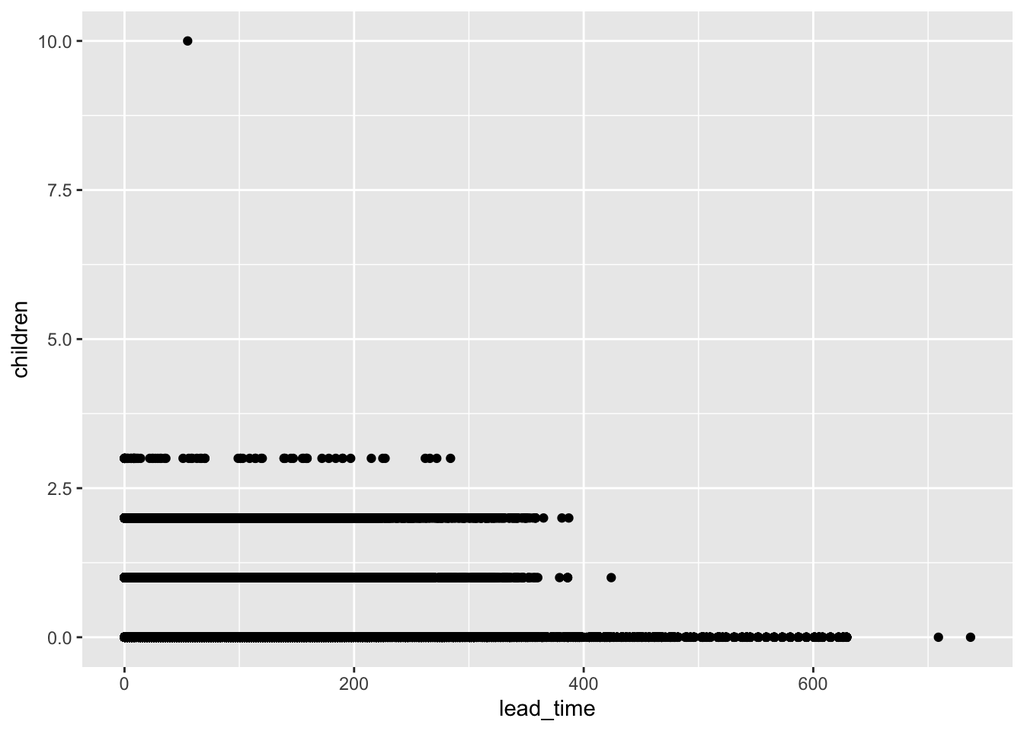

```r
ggplot(data = hotel_bookings) +
  geom_point(mapping = aes(x = lead_time, y = children))
```

We decide to create a bar chart showing each hotel type and market segment. We use different colors to represent each market segment:

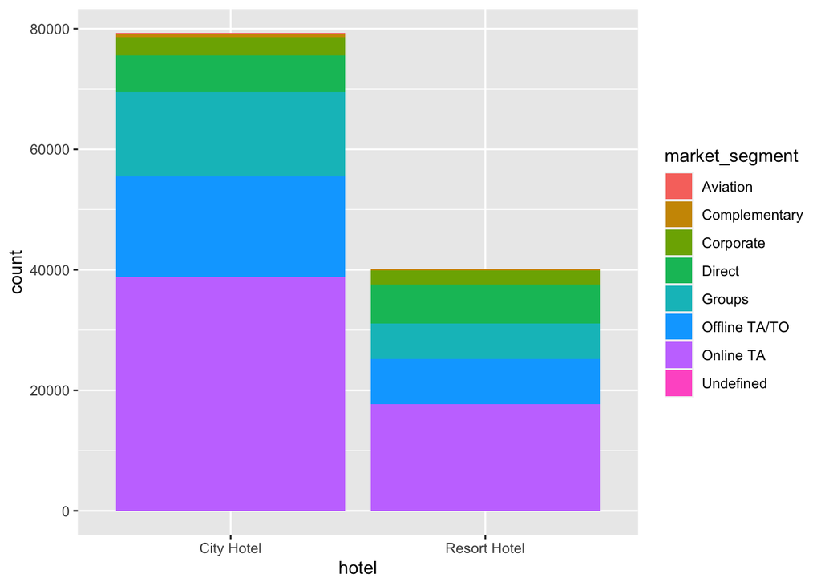

```r
ggplot(data = hotel_bookings) +
  geom_bar(mapping = aes(x = hotel, fill = market_segment))
```

We decide to use the facet_wrap() function to create a separate plot for each market segment:

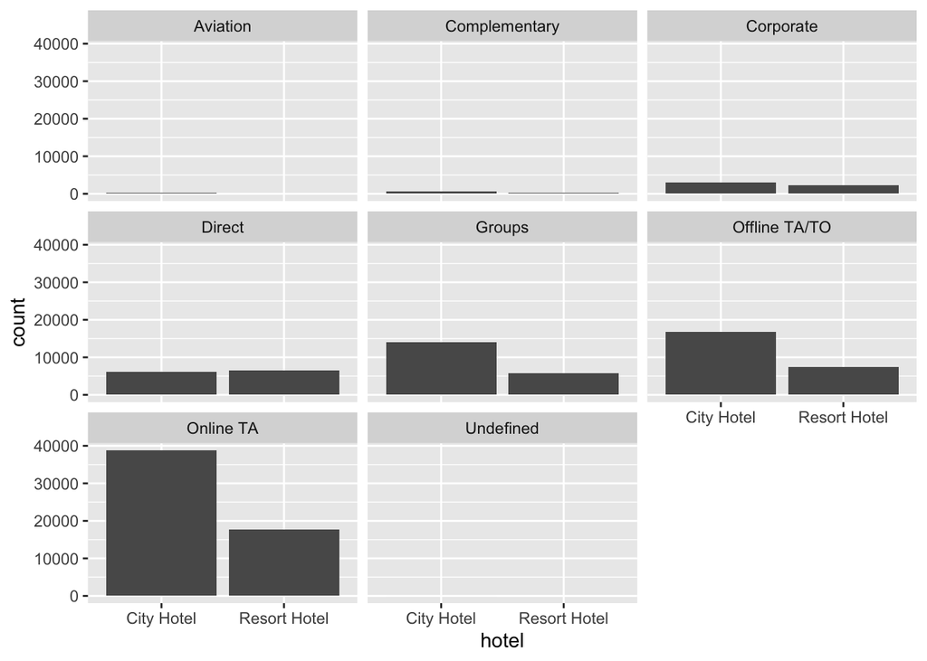

```r
ggplot(data = hotel_bookings) +
  geom_bar(mapping = aes(x = hotel)) +
  facet_wrap(~market_segment)
```

## Step 5: Filtering

For the next step, we will need to have the `tidyverse` package installed and loaded.

```r
#install.packages('tidyverse')
library(tidyverse)
```

Use the `filter()` function to create a data set that only includes the data we want:

```r
onlineta_city_hotels <- filter(hotel_bookings,
                           (hotel=="City Hotel" &
                             hotel_bookings$market_segment=="Online TA"))
```

We can use the`View`() function to check out our new data frame:

```r
#View(onlineta_city_hotels)
```

We can use the pipe operator (%>%) to do this in steps!

We name this data frame `onlineta_city_hotels_v2`:

```r
onlineta_city_hotels_v2 <- hotel_bookings %>%
  filter(hotel=="City Hotel") %>%
  filter(market_segment=="Online TA")
```

This code chunk generates the same data frame by using the `View()` function:

```r
#View(onlineta_city_hotels_v2)
```

## Step 6: Use our new dataframe

Using the code for our previous scatterplot, replace `data` with either `onlineta_city_hotels` to plot the data our stakeholder requested:

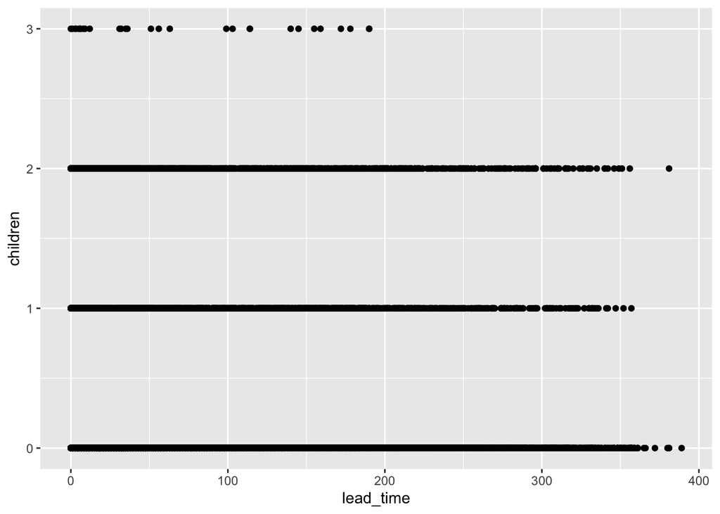

```r
ggplot(data = onlineta_city_hotels) +
  geom_point(mapping = aes(x = lead_time, y = children))
```

Based on our previous filter, this scatterplot shows data for online bookings for city hotels. The plot reveals that bookings with children tend to have a shorter lead time, and bookings with 3 children have a significantly shorter lead time (<200 days). So, promotions targeting families can be made closer to the valid booking dates.

## Wrap Up

Filters allow us to create different views of our data and allow us to investigate more specific relationships within our data.